# Data dictionary

- SK_ID_CURR = customer ID
- TARGET = label of an applicant being able to replay the loan or not. 1--> client with payment difficulties: he/she had late payment more than X days on at least one of the first Y installments of the loan in our sample and 0--> all other cases}
- NAME_CONTRACT_TYPE = loan contract type
- CODE_GENDER = gender info of an application - Female(F) or Male(M)
- FLAG_OWN_CAR = whether an applicant owns a car or not
- FLAG_OWN_REALTY = whether an applicant owns a realty or not
- CNT_CHILDREN = count of children an applicant has
- AMT_INCOME_TOTAL = total income amount
- AMT_CREDIT = total amount an applicant can borrow
- AMT_ANNUITY = annuity amount an applicant has
- AMT_GOODS_PRICE = the goods price an applicant is buying
- NAME_TYPE_SUITE = who was accompanying client when he was applying for the loan
- NAME_INCOME_TYPE = Clients income type (businessman, working, maternity leave,..)
- NAME_EDUCATION_TYPE = level of highest education the client achieved
- NAME_FAMILY_STATUS = marry status of an applicant
- NAME_HOUSING_TYPE = What is the housing situation of the client (renting, living with parents,...)
- REGION_POPULATION_RELATIVE = Normalized population of region where client lives (higher number means the client lives in more populated region)
- DAYS_BIRTH = Client's age in days at the time of application (time only relative to the application)
- DAYS_EMPLOYED = how many days before the application the person started current employment (time only relative to the application)
- DAYS_REGISTRATION = How many days before the application did client change his registration (time only relative to the application)
- DAYS_ID_PUBLISH = how many days before the application did client change the identity document with which he applied for the loan (time only relative to the application)
- FLAG_MOBIL = Did client provide mobile phone (1=YES, 0=NO)
- FLAG_EMP_PHONE = Did client provide employer phone (1=YES, 0=NO)
- FLAG_WORK_PHONE = Did client provide work phone (1=YES, 0=NO)
- FLAG_CONT_MOBILE = was mobile phone reachable (1=YES, 0=NO)
- FLAG_PHONE = did client provide home phone (1=YES, 0=NO)
- FLAG_EMAIL = did client provide email (1=YES, 0=NO)
- CNT_FAM_MEMBERS = how many family members does client have
- REGION_RATING_CLIENT = our rating of the region where client lives (1,2,3)
- REGION_RATING_CLIENT_W_CITY = our rating of the region where client lives with taking city into account (1,2,3)
- WEEKDAY_APPR_PROCESS_START = On which day of the week did the client apply for the loan (rounded)
- HOUR_APPR_PROCESS_START = Approximately at what hour did the client apply for the loan (rounded)
- REG_REGION_NOT_LIVE_REGION = Flag if client's permanent address does not match contact address (1=different, 0=same, at region level)
- REG_REGION_NOT_WORK_REGION = Flag if client's permanent address does not match work address (1=different, 0=same, at region level)
- LIVE_REGION_NOT_WORK_REGION = Flag if client's contact address does not match work address (1=different, 0=same, at region level)
- REG_CITY_NOT_LIVE_CITY = Flag if client's permanent address does not match contact address (1=different, 0=same, at city level)
- REG_CITY_NOT_WORK_CITY = Flag if client's permanent address does not match work address (1=different, 0=same, at city level)
- LIVE_CITY_NOT_WORK_CITY = Flag if client's contact address does not match work address (1=different, 0=same, at city level)
- ORGANIZATION_TYPE = Type of organization where client works
- EXT_SOURCE_2 = Normalized score from external data source
- EXT_SOURCE_3 = Normalized score from external data source
- OBS_30_CNT_SOCIAL_CIRCLE = How many observation of client's social surroundings with observable 30 DPD (days past due) default
- DEF_30_CNT_SOCIAL_CIRCLE = How many observation of client's social surroundings defaulted on 30 DPD (days past due)
- OBS_60_CNT_SOCIAL_CIRCLE = How many observation of client's social surroundings with observable 60 DPD (days past due) default
- DEF_60_CNT_SOCIAL_CIRCLE = How many observation of client's social surroundings defaulted on 60 DPD (days past due)
- DAYS_LAST_PHONE_CHANGE = How many days before application did client change phone
- FLAG_DOCUMENT_2 = Did client provide document 2
- FLAG_DOCUMENT_3 = Did client provide document 3
- FLAG_DOCUMENT_4 = Did client provide document 4
- FLAG_DOCUMENT_5 = Did client provide document 5
- FLAG_DOCUMENT_6 = Did client provide document 6
- FLAG_DOCUMENT_7 = Did client provide document 7
- FLAG_DOCUMENT_8 = Did client provide document 8
- FLAG_DOCUMENT_9 = Did client provide document 9
- FLAG_DOCUMENT_10 = Did client provide document 10
- FLAG_DOCUMENT_11 = Did client provide document 11
- FLAG_DOCUMENT_12 = Did client provide document 12
- FLAG_DOCUMENT_13 = Did client provide document 13
- FLAG_DOCUMENT_14 = Did client provide document 14
- FLAG_DOCUMENT_15 = Did client provide document 15
- FLAG_DOCUMENT_16 = Did client provide document 16
- FLAG_DOCUMENT_17 = Did client provide document 17
- FLAG_DOCUMENT_18 = Did client provide document 18
- FLAG_DOCUMENT_19 = Did client provide document 19
- FLAG_DOCUMENT_20 = Did client provide document 20
- FLAG_DOCUMENT_21 = Did client provide document 21
- AMT_REQ_CREDIT_BUREAU_HOUR = Number of enquiries to Credit Bureau about the client one hour before application
- AMT_REQ_CREDIT_BUREAU_DAY = Number of enquiries to Credit Bureau about the client one day before application (excluding one hour before application)
- AMT_REQ_CREDIT_BUREAU_WEEK = Number of enquiries to Credit Bureau about the client one week before application (excluding one day before application)
- AMT_REQ_CREDIT_BUREAU_MON = Number of enquiries to Credit Bureau about the client one month before application (excluding one week before application)
- AMT_REQ_CREDIT_BUREAU_QRT = Number of enquiries to Credit Bureau about the client 3 month before application (excluding one month before application)
- AMT_REQ_CREDIT_BUREAU_YEAR = Number of enquiries to Credit Bureau about the client 1 year before application (excluding 3 month before application)

# Step 1: Data understanding

- Import data
- Collect inital data
- Describe data
- Verify data quality

(Hotz, 2023)

### Step 1.1 - Import necessary libraries and load the dataset

```python
import pandas as pd # For reading and analysing data
import numpy as np # For mathematical operations on arrays
import matplotlib.pyplot as plt # For visualisation
import seaborn as sns # For visualisation
# (So, 2023)

# Import the datasets with Pandas read_csv function
df = pd.read_csv("loan_data_training.csv")
unknown_df = pd.read_csv("loan_data_unknown.csv")

# Set the display option to show all columns
pd.set_option('display.max_columns', None)

# Display first 5 rows
df.head()

# (So, 2023)
```

|  | SK_ID_CURR | TARGET | NAME_CONTRACT_TYPE | CODE_GENDER | FLAG_OWN_CAR | FLAG_OWN_REALTY | CNT_CHILDREN | AMT_INCOME_TOTAL | AMT_CREDIT | AMT_ANNUITY | AMT_GOODS_PRICE | NAME_TYPE_SUITE | NAME_INCOME_TYPE | NAME_EDUCATION_TYPE | NAME_FAMILY_STATUS | NAME_HOUSING_TYPE | REGION_POPULATION_RELATIVE | DAYS_BIRTH | DAYS_EMPLOYED | DAYS_REGISTRATION | DAYS_ID_PUBLISH | FLAG_MOBIL | FLAG_EMP_PHONE | FLAG_WORK_PHONE | FLAG_CONT_MOBILE | FLAG_PHONE | FLAG_EMAIL | CNT_FAM_MEMBERS | REGION_RATING_CLIENT | … |
| --- | --- | --- | --- | --- | --- | --- | --- | --- | --- | --- | --- | --- | --- | --- | --- | --- | --- | --- | --- | --- | --- | --- | --- | --- | --- | --- | --- | --- | --- | --- |
| 0 | 100002 | 1 | Cash loans | M | N | Y | 0 | 202500.0 | 406597.5 | 24700.5 | 351000.0 | Unaccompanied | Working | Secondary / secondary special | Single / not married | House / apartment | 0.018801 | -9461 | -637 | -3648.0 | -2120 | 1 | 1 | 0 | 1 | 1 | 0 | 1.0 | 2 | … |
| 1 | 100031 | 1 | Cash loans | F | N | Y | 0 | 112500.0 | 979992.0 | 27076.5 | 702000.0 | Unaccompanied | Working | Secondary / secondary special | Widow | House / apartment | 0.018029 | -18724 | -2628 | -6573.0 | -1827 | 1 | 1 | 0 | 1 | 0 | 0 | 1.0 | 3 | … |
| 2 | 100047 | 1 | Cash loans | M | N | Y | 0 | 202500.0 | 1193580.0 | 35028.0 | 855000.0 | Unaccompanied | Commercial associate | Secondary / secondary special | Married | House / apartment | 0.025164 | -17482 | -1262 | -1182.0 | -1029 | 1 | 1 | 0 | 1 | 0 | 0 | 2.0 | 2 | … |
| 3 | 100049 | 1 | Cash loans | F | N | N | 0 | 135000.0 | 288873.0 | 16258.5 | 238500.0 | Unaccompanied | Working | Secondary / secondary special | Civil marriage | House / apartment | 0.007305 | -13384 | -3597 | -45.0 | -4409 | 1 | 1 | 1 | 1 | 1 | 0 | 2.0 | 3 | … |
| 4 | 100112 | 1 | Cash loans | M | Y | Y | 0 | 315000.0 | 953460.0 | 64107.0 | 900000.0 | Family | Commercial associate | Incomplete higher | Single / not married | With parents | 0.030755 | -10199 | -2015 | -4802.0 | -1038 | 1 | 1 | 0 | 1 | 0 | 0 | 1.0 | 2 | … |

### Step 1.2 - Collect inital data

```python
# Display the shape of the df
df.shape
```

```
(42452, 72)
```

```python
# Look at 5 random rows of the df
df.sample(5)
```

|  | SK_ID_CURR | TARGET | NAME_CONTRACT_TYPE | CODE_GENDER | FLAG_OWN_CAR | FLAG_OWN_REALTY | CNT_CHILDREN | AMT_INCOME_TOTAL | AMT_CREDIT | AMT_ANNUITY | AMT_GOODS_PRICE | NAME_TYPE_SUITE | NAME_INCOME_TYPE | NAME_EDUCATION_TYPE | NAME_FAMILY_STATUS | NAME_HOUSING_TYPE | REGION_POPULATION_RELATIVE | DAYS_BIRTH | DAYS_EMPLOYED | DAYS_REGISTRATION | DAYS_ID_PUBLISH | FLAG_MOBIL | FLAG_EMP_PHONE | FLAG_WORK_PHONE | FLAG_CONT_MOBILE | FLAG_PHONE | FLAG_EMAIL | CNT_FAM_MEMBERS | REGION_RATING_CLIENT | … |
| --- | --- | --- | --- | --- | --- | --- | --- | --- | --- | --- | --- | --- | --- | --- | --- | --- | --- | --- | --- | --- | --- | --- | --- | --- | --- | --- | --- | --- | --- | --- |
| 18600 | 428500 | 1 | Cash loans | F | Y | Y | 1 | 76500.0 | 225000.0 | 15034.5 | 225000.0 | Unaccompanied | Working | Secondary / secondary special | Married | House / apartment | 0.009549 | -13922 | -1140 | -1369.0 | -4186 | 1 | 1 | 0 | 1 | 1 | 0 | 3.0 | 2 | … |
| 32298 | 298710 | 0 | Cash loans | F | N | Y | 0 | 67500.0 | 135000.0 | 6075.0 | 135000.0 | Unaccompanied | Pensioner | Secondary / secondary special | Widow | House / apartment | 0.020713 | -22610 | 365243 | -6813.0 | -4005 | 1 | 0 | 0 | 1 | 1 | 0 | 1.0 | 3 | … |
| 29352 | 155536 | 0 | Cash loans | F | N | Y | 0 | 157500.0 | 755190.0 | 33264.0 | 675000.0 | Unaccompanied | State servant | Secondary / secondary special | Married | House / apartment | 0.018850 | -16950 | -4889 | -6533.0 | -482 | 1 | 1 | 0 | 1 | 1 | 0 | 2.0 | 2 | … |
| 32995 | 398383 | 0 | Cash loans | F | Y | N | 0 | 270000.0 | 1971072.0 | 68643.0 | 1800000.0 | Unaccompanied | Commercial associate | Secondary / secondary special | Civil marriage | House / apartment | 0.032561 | -21327 | -2387 | -8458.0 | -4814 | 1 | 1 | 1 | 1 | 1 | 1 | 2.0 | 1 | … |
| 12139 | 313452 | 1 | Cash loans | M | Y | Y | 0 | 90000.0 | 760225.5 | 30280.5 | 679500.0 | Unaccompanied | Working | Secondary / secondary special | Married | House / apartment | 0.018634 | -17396 | -658 | -1453.0 | -751 | 1 | 1 | 1 | 1 | 0 | 0 | 2.0 | 2 | … |

### Step 1.3 - Describe data

```python
# Check how many rows and columns, how many non-null values and datatype of the datasets
df.info()
```

```
<class 'pandas.core.frame.DataFrame'>
RangeIndex: 42452 entries, 0 to 42451
Data columns (total 72 columns):
 #   Column                       Non-Null Count  Dtype
---  ------                       --------------  -----
 0   SK_ID_CURR                   42452 non-null  int64
 1   TARGET                       42452 non-null  int64
 2   NAME_CONTRACT_TYPE           42452 non-null  object
 3   CODE_GENDER                  42452 non-null  object
 4   FLAG_OWN_CAR                 42452 non-null  object
 5   FLAG_OWN_REALTY              42452 non-null  object
 6   CNT_CHILDREN                 42452 non-null  int64
 7   AMT_INCOME_TOTAL             42452 non-null  float64
 8   AMT_CREDIT                   42452 non-null  float64
 9   AMT_ANNUITY                  42451 non-null  float64
```

[output cut: 64 more lines]

```python
# Get a quick statistical overview of the data
df.describe()
```

|  | SK_ID_CURR | TARGET | CNT_CHILDREN | AMT_INCOME_TOTAL | AMT_CREDIT | AMT_ANNUITY | AMT_GOODS_PRICE | REGION_POPULATION_RELATIVE | DAYS_BIRTH | DAYS_EMPLOYED | DAYS_REGISTRATION | DAYS_ID_PUBLISH | FLAG_MOBIL | FLAG_EMP_PHONE | FLAG_WORK_PHONE | FLAG_CONT_MOBILE | FLAG_PHONE | FLAG_EMAIL | CNT_FAM_MEMBERS | REGION_RATING_CLIENT | REGION_RATING_CLIENT_W_CITY | HOUR_APPR_PROCESS_START | REG_REGION_NOT_LIVE_REGION | REG_REGION_NOT_WORK_REGION | LIVE_REGION_NOT_WORK_REGION | REG_CITY_NOT_LIVE_CITY | REG_CITY_NOT_WORK_CITY | LIVE_CITY_NOT_WORK_CITY | EXT_SOURCE_2 | … |
| --- | --- | --- | --- | --- | --- | --- | --- | --- | --- | --- | --- | --- | --- | --- | --- | --- | --- | --- | --- | --- | --- | --- | --- | --- | --- | --- | --- | --- | --- | --- |
| count | 42452.000000 | 42452.000000 | 42452.000000 | 4.245200e+04 | 4.245200e+04 | 42451.000000 | 4.240400e+04 | 42452.000000 | 42452.000000 | 42452.000000 | 42452.000000 | 42452.000000 | 42452.0 | 42452.000000 | 42452.000000 | 42452.000000 | 42452.000000 | 42452.000000 | 42451.000000 | 42452.000000 | 42452.000000 | 42452.000000 | 42452.000000 | 42452.000000 | 42452.000000 | 42452.000000 | 42452.000000 | 42452.000000 | 42361.000000 | … |
| mean | 277315.176576 | 0.473688 | 0.439909 | 1.679925e+05 | 5.807821e+05 | 26890.149160 | 5.173178e+05 | 0.020061 | -15541.240625 | 55200.637096 | -4765.724655 | -2881.686705 | 1.0 | 0.843894 | 0.218294 | 0.998021 | 0.267596 | 0.056158 | 2.168547 | 2.098558 | 2.078206 | 11.954419 | 0.016301 | 0.052883 | 0.041152 | 0.097004 | 0.261095 | 0.195114 | 0.470201 | … |
| std | 102659.447840 | 0.499313 | 0.735971 | 5.747859e+05 | 3.794974e+05 | 13716.494534 | 3.468770e+05 | 0.012949 | 4339.512229 | 133340.293080 | 3446.768936 | 1523.892866 | 0.0 | 0.362960 | 0.413093 | 0.044439 | 0.442711 | 0.230228 | 0.926473 | 0.510095 | 0.504773 | 3.276659 | 0.126631 | 0.223803 | 0.198645 | 0.295966 | 0.439237 | 0.396293 | 0.206936 | … |
| min | 100002.000000 | 0.000000 | 0.000000 | 2.565000e+04 | 4.500000e+04 | 2173.500000 | 4.500000e+04 | 0.000290 | -25192.000000 | -16836.000000 | -20514.000000 | -6383.000000 | 1.0 | 0.000000 | 0.000000 | 0.000000 | 0.000000 | 0.000000 | 1.000000 | 1.000000 | 1.000000 | 0.000000 | 0.000000 | 0.000000 | 0.000000 | 0.000000 | 0.000000 | 0.000000 | 0.000005 | … |
| 25% | 188808.000000 | 0.000000 | 0.000000 | 1.125000e+05 | 2.762775e+05 | 16875.000000 | 2.385000e+05 | 0.010006 | -19039.000000 | -2504.000000 | -7116.000000 | -4228.000000 | 1.0 | 1.000000 | 0.000000 | 1.000000 | 0.000000 | 0.000000 | 2.000000 | 2.000000 | 2.000000 | 10.000000 | 0.000000 | 0.000000 | 0.000000 | 0.000000 | 0.000000 | 0.000000 | 0.313141 | … |
| 50% | 276289.000000 | 0.000000 | 0.000000 | 1.440000e+05 | 5.073390e+05 | 25056.000000 | 4.500000e+05 | 0.018801 | -15083.500000 | -1120.000000 | -4296.000000 | -3058.000000 | 1.0 | 1.000000 | 0.000000 | 1.000000 | 0.000000 | 0.000000 | 2.000000 | 2.000000 | 2.000000 | 12.000000 | 0.000000 | 0.000000 | 0.000000 | 0.000000 | 0.000000 | 0.000000 | 0.520409 | … |
| 75% | 366068.500000 | 1.000000 | 1.000000 | 2.025000e+05 | 7.819200e+05 | 34128.000000 | 6.750000e+05 | 0.026392 | -11893.000000 | -331.000000 | -1848.000000 | -1553.000000 | 1.0 | 1.000000 | 0.000000 | 1.000000 | 1.000000 | 0.000000 | 3.000000 | 2.000000 | 2.000000 | 14.000000 | 0.000000 | 0.000000 | 0.000000 | 0.000000 | 1.000000 | 0.000000 | 0.638548 | … |
| max | 456242.000000 | 1.000000 | 11.000000 | 1.170000e+08 | 4.027680e+06 | 225000.000000 | 3.600000e+06 | 0.072508 | -7678.000000 | 365243.000000 | 0.000000 | -1.000000 | 1.0 | 1.000000 | 1.000000 | 1.000000 | 1.000000 | 1.000000 | 13.000000 | 3.000000 | 3.000000 | 23.000000 | 1.000000 | 1.000000 | 1.000000 | 1.000000 | 1.000000 | 1.000000 | 0.855000 | … |

```python
# Display all unique values for each column in the DataFrame
for col in df.columns:
    unique_values = df[col].unique()
    print(f'Unique values in {col}:')
    print(unique_values)
    print()

# (Ghenis, 2014)
```

```
Unique values in SK_ID_CURR:
[100002 100031 100047 ... 301623 324813 136311]

Unique values in TARGET:
[1 0]

Unique values in NAME_CONTRACT_TYPE:
['Cash loans' 'Revolving loans']

Unique values in CODE_GENDER:
['M' 'F']

Unique values in FLAG_OWN_CAR:
['N' 'Y']

Unique values in FLAG_OWN_REALTY:
['Y' 'N']

Unique values in CNT_CHILDREN:
[ 0  1  3  2  4  5  9 11  6  7]

Unique values in AMT_INCOME_TOTAL:
[2.025000e+05 1.125000e+05 1.350000e+05 3.150000e+05 1.575000e+05
 2.925000e+05 1.119150e+05 1.800000e+05 7.334100e+04 1.215000e+05
 2.250000e+05 6.300000e+04 3.600000e+04 8.100000e+04 1.710000e+05
 2.700000e+05 2.115000e+05 9.900000e+04 4.050000e+05 4.500000e+05
 1.170000e+05 9.450000e+04 5.400000e+05 1.260000e+05 1.440000e+05
 3.600000e+05 4.694850e+04 1.530000e+05 8.775000e+04 9.000000e+04
 2.475000e+05 6.750000e+05 1.755000e+05 7.650000e+04 2.205000e+05
 6.975000e+05 1.305000e+05 2.880000e+05 2.295000e+05 4.950000e+04
 6.750000e+04 1.080000e+05 3.825000e+05 5.400000e+04 1.395000e+05
 8.550000e+04 3.330000e+05 4.500000e+04 1.035000e+05 3.375000e+05
 5.850000e+04 1.665000e+05 8.330400e+04 1.485000e+05 1.845000e+05
 2.513250e+05 6.502500e+04 7.200000e+04 1.620000e+05 2.160000e+05
 2.655000e+05 2.520000e+05 8.415000e+04 1.422000e+05 1.890000e+05
 1.935000e+05 3.915000e+05 6.615000e+04 4.050000e+04 4.635000e+05
 2.610000e+05 2.340000e+05 7.785000e+04 2.070000e+05 5.415750e+04
 6.660000e+04 9.090000e+04 1.417500e+05 2.565000e+05 3.510000e+05
 9.225000e+04 4.950000e+05 2.430000e+05 8.325000e+04 2.385000e+05
 4.185000e+05 2.526750e+05 1.170000e+08 5.850000e+05 7.335000e+04
```

[output cut: 577 more lines]

```
[ 0. nan  1.  2.  4.  3.  6.]

Unique values in AMT_REQ_CREDIT_BUREAU_WEEK:
[ 0. nan  1.  2.  3.  4.  6.  5.]

Unique values in AMT_REQ_CREDIT_BUREAU_MON:
[ 0.  2. nan  6.  1.  3.  7.  5.  4. 15. 12. 10. 11.  8. 13.  9. 17. 14.
 18. 16.]

Unique values in AMT_REQ_CREDIT_BUREAU_QRT:
[ 0.  2. nan  1.  3.  6.  4.  7.  5. 19.]

Unique values in AMT_REQ_CREDIT_BUREAU_YEAR:
[ 1.  2.  4.  0. nan  3.  7.  6.  8.  5.  9. 11. 16. 22. 10. 14. 12. 13.
 17.]
```

```python
df['TARGET'].value_counts()
```

```
0    22343
1    20109
Name: TARGET, dtype: int64
```

### Step 1.4 - Explore data

```python
import pandas as pd
from scipy.stats import pearsonr, pointbiserialr, f_oneway

# Read the data
df = pd.read_csv("loan_data_training.csv")

# Extract the target variable
target = df['TARGET']

# Create lists to store feature types
numeric_features = []
binary_categorical_features = []
non_binary_categorical_features = []

# Determine the type of each feature
for column in df.columns:
    if df[column].dtype in ['int64', 'float64'] and column != 'TARGET':
        numeric_features.append(column)
    elif df[column].dtype == 'object':
        unique_values = df[column].nunique()
        if unique_values == 2:
            binary_categorical_features.append(column)
        elif unique_values > 2:
            non_binary_categorical_features.append(column)

# Compute Pearson correlation for numeric features
numeric_correlations = {}
for feature in numeric_features:
    if df[feature].notna().all(): # Only use if there are no missing values
        numeric_correlations[feature] = pearsonr(df[feature], target)[0]

# Compute Point-Biserial correlation for binary categorical features
binary_correlations = {}
for feature in binary_categorical_features:
    if df[feature].notna().all(): # Only use if there are no missing values
        df[feature] = pd.Categorical(df[feature])
        binary_correlations[feature] = pointbiserialr(df[feature].cat.codes, target)[0]

# Compute ANOVA for non-binary categorical features
anova_results = {}
for feature in non_binary_categorical_features:
    categories = list(df[feature].dropna().unique())
    data = [target[df[feature] == category] for category in categories]
    F, p = f_oneway(*data)
    anova_results[feature] = {'F-value': F, 'p-value': p}

print("Numeric Feature Correlations:")
print(numeric_correlations)
print("\nBinary Categorical Feature Correlations:")
print(binary_correlations)
print("\nANOVA results for Non-Binary Categorical Features:")
print(anova_results)

# (Brownlee, 2020)
# (DeJesus, 2021)
# (Dong, 2023)
# (Lee, 2022)
# (So, 2023)
# (OpenAI, 2023)
```

```
Numeric Feature Correlations:
{'SK_ID_CURR': -0.0017663464247772863, 'CNT_CHILDREN': 0.028261612755049976, 'AMT_INCOME_TOTAL': -0.0017728989507332085, 'AMT_CREDIT': -0.05948476286777749, 'REGION_POPULATION_RELATIVE': -0.06993047761748138, 'DAYS_BIRTH': 0.14781245384475317, 'DAYS_EMPLOYED': -0.08966057484393117, 'DAYS_REGISTRATIO…

Binary Categorical Feature Correlations:
{'NAME_CONTRACT_TYPE': -0.05383702047821619, 'CODE_GENDER': 0.09869205410006862, 'FLAG_OWN_CAR': -0.047984330242089535, 'FLAG_OWN_REALTY': -0.01202999014208304}

ANOVA results for Non-Binary Categorical Features:
{'NAME_TYPE_SUITE': {'F-value': 1.692019122082414, 'p-value': 0.11842028260452088}, 'NAME_INCOME_TYPE': {'F-value': 106.7654767234741, 'p-value': 4.326261953604606e-134}, 'NAME_EDUCATION_TYPE': {'F-value': 133.02462340576562, 'p-value': 3.9417630363606424e-113}, 'NAME_FAMILY_STATUS': {'F-value': 50.…
```

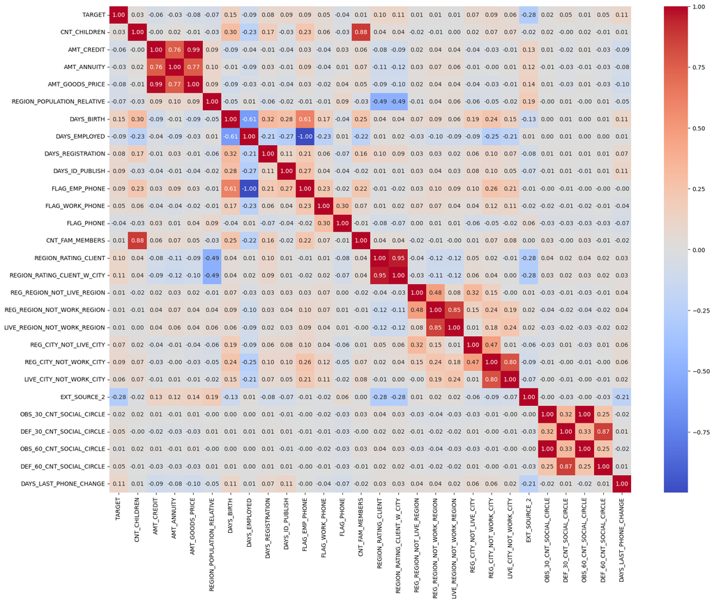

```python
# List of desired features
corr_features = [
    'TARGET', 'NAME_CONTRACT_TYPE', 'CODE_GENDER', 'FLAG_OWN_CAR', 'FLAG_OWN_REALTY',
    'CNT_CHILDREN', 'AMT_CREDIT', 'AMT_ANNUITY', 'AMT_GOODS_PRICE', 'NAME_TYPE_SUITE',
    'NAME_INCOME_TYPE', 'NAME_EDUCATION_TYPE', 'NAME_FAMILY_STATUS', 'NAME_HOUSING_TYPE',
    'REGION_POPULATION_RELATIVE', 'DAYS_BIRTH', 'DAYS_EMPLOYED', 'DAYS_REGISTRATION',
    'DAYS_ID_PUBLISH', 'FLAG_EMP_PHONE', 'FLAG_WORK_PHONE', 'FLAG_PHONE', 'CNT_FAM_MEMBERS',
    'REGION_RATING_CLIENT', 'REGION_RATING_CLIENT_W_CITY', 'REG_REGION_NOT_LIVE_REGION',
    'REG_REGION_NOT_WORK_REGION', 'LIVE_REGION_NOT_WORK_REGION', 'REG_CITY_NOT_LIVE_CITY',
    'REG_CITY_NOT_WORK_CITY', 'LIVE_CITY_NOT_WORK_CITY', 'ORGANIZATION_TYPE', 'EXT_SOURCE_2',
    'OBS_30_CNT_SOCIAL_CIRCLE', 'DEF_30_CNT_SOCIAL_CIRCLE', 'OBS_60_CNT_SOCIAL_CIRCLE',
    'DEF_60_CNT_SOCIAL_CIRCLE', 'DAYS_LAST_PHONE_CHANGE'
]

# Filter the dataframe to include only the desired features
df_filtered = df[corr_features]

# Compute correlation matrix
corr_matrix = df_filtered.corr()

# Use seaborn to plot the heatmap
plt.figure(figsize=(20, 15))
sns.heatmap(corr_matrix, annot=True, cmap="coolwarm", fmt=".2f")
plt.show()
# (So, 2023)
```

### Step 1.5 - Verify data quality

```python
# Check for missing values and display all features containing rows with more than 0 missing values.
# The dataset has multiples columns with missing values
print(df.isnull().sum()[df.isnull().sum() > 0])
# (So, 2023)
```

```
AMT_ANNUITY                      1
AMT_GOODS_PRICE                 48
NAME_TYPE_SUITE                159
CNT_FAM_MEMBERS                  1
EXT_SOURCE_2                    91
EXT_SOURCE_3                  8966
OBS_30_CNT_SOCIAL_CIRCLE       105
DEF_30_CNT_SOCIAL_CIRCLE       105
OBS_60_CNT_SOCIAL_CIRCLE       105
DEF_60_CNT_SOCIAL_CIRCLE       105
AMT_REQ_CREDIT_BUREAU_HOUR    6431
AMT_REQ_CREDIT_BUREAU_DAY     6431
AMT_REQ_CREDIT_BUREAU_WEEK    6431
AMT_REQ_CREDIT_BUREAU_MON     6431
AMT_REQ_CREDIT_BUREAU_QRT     6431
AMT_REQ_CREDIT_BUREAU_YEAR    6431
dtype: int64
```

```python
# Check for duplicates, the dataset has none
df.duplicated().sum()
```

```
0
```

# Step 2: Data Preparation

- Select data
- Clean data
- Format data
- Split data

(Hotz, 2023)

### Step 2.1 - Select data

## Selected features for modeling

- TARGET = label of an applicant being able to replay the loan or not. 1--> client with payment difficulties: he/she had late payment more than X days on at least one of the first Y installments of the loan in our sample and 0--> all other cases}
- NAME_CONTRACT_TYPE = loan contract type
- CODE_GENDER = gender info of an application - Female(F) or Male(M)
- FLAG_OWN_CAR = whether an applicant owns a car or not
- FLAG_OWN_REALTY = whether an applicant owns a realty or not
- CNT_CHILDREN = count of children an applicant has
- AMT_CREDIT = total amount an applicant can borrow
- AMT_ANNUITY = annuity amount an applicant has
- NAME_INCOME_TYPE = Clients income type (businessman, working, maternity leave,..)
- NAME_EDUCATION_TYPE = level of highest education the client achieved
- NAME_FAMILY_STATUS = marry status of an applicant
- NAME_HOUSING_TYPE = What is the housing situation of the client (renting, living with parents,...)
- DAYS_BIRTH = Client's age in days at the time of application (time only relative to the application)
- DAYS_EMPLOYED = how many days before the application the person started current employment (time only relative to the application)
- DAYS_REGISTRATION = How many days before the application did client change his registration (time only relative to the application)
- DAYS_ID_PUBLISH = how many days before the application did client change the identity document with which he applied for the loan (time only relative to the application)
- FLAG_PHONE = did client provide home phone (1=YES, 0=NO)
- REGION_RATING_CLIENT_W_CITY = our rating of the region where client lives with taking city into account (1,2,3)
- REG_REGION_NOT_LIVE_REGION = Flag if client's permanent address does not match contact address (1=different, 0=same, at region level)
- REG_REGION_NOT_WORK_REGION = Flag if client's permanent address does not match work address (1=different, 0=same, at region level)
- LIVE_REGION_NOT_WORK_REGION = Flag if client's contact address does not match work address (1=different, 0=same, at region level)
- REG_CITY_NOT_LIVE_CITY = Flag if client's permanent address does not match contact address (1=different, 0=same, at city level)
- ORGANIZATION_TYPE = Type of organization where client works
- EXT_SOURCE_2 = Normalized score from external data source
- OBS_60_CNT_SOCIAL_CIRCLE = How many observation of client's social surroundings with observable 60 DPD (days past due) default
- DEF_60_CNT_SOCIAL_CIRCLE = How many observation of client's social surroundings defaulted on 60 DPD (days past due)
- SK_ID_CURR = customer ID

```python
# Create a copy of the dataframe with chosen features

selected_features = [
    "TARGET", "NAME_CONTRACT_TYPE", "CODE_GENDER", "FLAG_OWN_CAR",
    "FLAG_OWN_REALTY", "CNT_CHILDREN", "AMT_CREDIT", "AMT_ANNUITY",
    "NAME_INCOME_TYPE", "NAME_EDUCATION_TYPE",
    "NAME_FAMILY_STATUS", "NAME_HOUSING_TYPE", "DAYS_BIRTH", "DAYS_EMPLOYED",
    "DAYS_REGISTRATION", "DAYS_ID_PUBLISH", "FLAG_PHONE",
    "REGION_RATING_CLIENT_W_CITY", "REG_REGION_NOT_LIVE_REGION",
    "REG_REGION_NOT_WORK_REGION", "LIVE_REGION_NOT_WORK_REGION",
    "REG_CITY_NOT_LIVE_CITY", "ORGANIZATION_TYPE", "EXT_SOURCE_2",
    "OBS_60_CNT_SOCIAL_CIRCLE", "DEF_60_CNT_SOCIAL_CIRCLE", "SK_ID_CURR"
]

df_clean = df[selected_features].copy()
```

```python
df_clean.head()
```

|  | TARGET | NAME_CONTRACT_TYPE | CODE_GENDER | FLAG_OWN_CAR | FLAG_OWN_REALTY | CNT_CHILDREN | AMT_CREDIT | AMT_ANNUITY | NAME_INCOME_TYPE | NAME_EDUCATION_TYPE | NAME_FAMILY_STATUS | NAME_HOUSING_TYPE | DAYS_BIRTH | DAYS_EMPLOYED | DAYS_REGISTRATION | DAYS_ID_PUBLISH | FLAG_PHONE | REGION_RATING_CLIENT_W_CITY | REG_REGION_NOT_LIVE_REGION | REG_REGION_NOT_WORK_REGION | LIVE_REGION_NOT_WORK_REGION | REG_CITY_NOT_LIVE_CITY | ORGANIZATION_TYPE | EXT_SOURCE_2 | OBS_60_CNT_SOCIAL_CIRCLE | DEF_60_CNT_SOCIAL_CIRCLE | SK_ID_CURR |
| --- | --- | --- | --- | --- | --- | --- | --- | --- | --- | --- | --- | --- | --- | --- | --- | --- | --- | --- | --- | --- | --- | --- | --- | --- | --- | --- | --- |
| 0 | 1 | Cash loans | M | N | Y | 0 | 406597.5 | 24700.5 | Working | Secondary / secondary special | Single / not married | House / apartment | -9461 | -637 | -3648.0 | -2120 | 1 | 2 | 0 | 0 | 0 | 0 | Business Entity Type 3 | 0.262949 | 2.0 | 2.0 | 100002 |
| 1 | 1 | Cash loans | F | N | Y | 0 | 979992.0 | 27076.5 | Working | Secondary / secondary special | Widow | House / apartment | -18724 | -2628 | -6573.0 | -1827 | 0 | 2 | 0 | 0 | 0 | 0 | Business Entity Type 3 | 0.548477 | 10.0 | 0.0 | 100031 |
| 2 | 1 | Cash loans | M | N | Y | 0 | 1193580.0 | 35028.0 | Commercial associate | Secondary / secondary special | Married | House / apartment | -17482 | -1262 | -1182.0 | -1029 | 0 | 2 | 0 | 0 | 0 | 0 | Business Entity Type 3 | 0.306841 | 0.0 | 0.0 | 100047 |
| 3 | 1 | Cash loans | F | N | N | 0 | 288873.0 | 16258.5 | Working | Secondary / secondary special | Civil marriage | House / apartment | -13384 | -3597 | -45.0 | -4409 | 1 | 3 | 0 | 0 | 0 | 0 | Self-employed | 0.674203 | 1.0 | 0.0 | 100049 |
| 4 | 1 | Cash loans | M | Y | Y | 0 | 953460.0 | 64107.0 | Commercial associate | Incomplete higher | Single / not married | With parents | -10199 | -2015 | -4802.0 | -1038 | 0 | 2 | 0 | 0 | 0 | 0 | Industry: type 4 | 0.432340 | 0.0 | 0.0 | 100112 |

```python
df_clean.info()
```

```
<class 'pandas.core.frame.DataFrame'>
RangeIndex: 42452 entries, 0 to 42451
Data columns (total 27 columns):
 #   Column                       Non-Null Count  Dtype
---  ------                       --------------  -----
 0   TARGET                       42452 non-null  int64
 1   NAME_CONTRACT_TYPE           42452 non-null  category
 2   CODE_GENDER                  42452 non-null  category
 3   FLAG_OWN_CAR                 42452 non-null  category
 4   FLAG_OWN_REALTY              42452 non-null  category
 5   CNT_CHILDREN                 42452 non-null  int64
 6   AMT_CREDIT                   42452 non-null  float64
 7   AMT_ANNUITY                  42451 non-null  float64
 8   NAME_INCOME_TYPE             42452 non-null  object
 9   NAME_EDUCATION_TYPE          42452 non-null  object
```

[output cut: 19 more lines]

```python
df_clean.describe()
```

|  | TARGET | CNT_CHILDREN | AMT_CREDIT | AMT_ANNUITY | DAYS_BIRTH | DAYS_EMPLOYED | DAYS_REGISTRATION | DAYS_ID_PUBLISH | FLAG_PHONE | REGION_RATING_CLIENT_W_CITY | REG_REGION_NOT_LIVE_REGION | REG_REGION_NOT_WORK_REGION | LIVE_REGION_NOT_WORK_REGION | REG_CITY_NOT_LIVE_CITY | EXT_SOURCE_2 | OBS_60_CNT_SOCIAL_CIRCLE | DEF_60_CNT_SOCIAL_CIRCLE | SK_ID_CURR |
| --- | --- | --- | --- | --- | --- | --- | --- | --- | --- | --- | --- | --- | --- | --- | --- | --- | --- | --- |
| count | 42452.000000 | 42452.000000 | 4.245200e+04 | 42451.000000 | 42452.000000 | 42452.000000 | 42452.000000 | 42452.000000 | 42452.000000 | 42452.000000 | 42452.000000 | 42452.000000 | 42452.000000 | 42452.000000 | 42361.000000 | 42347.000000 | 42347.000000 | 42452.000000 |
| mean | 0.473688 | 0.439909 | 5.807821e+05 | 26890.149160 | -15541.240625 | 55200.637096 | -4765.724655 | -2881.686705 | 0.267596 | 2.078206 | 0.016301 | 0.052883 | 0.041152 | 0.097004 | 0.470201 | 1.443691 | 0.117930 | 277315.176576 |
| std | 0.499313 | 0.735971 | 3.794974e+05 | 13716.494534 | 4339.512229 | 133340.293080 | 3446.768936 | 1523.892866 | 0.442711 | 0.504773 | 0.126631 | 0.223803 | 0.198645 | 0.295966 | 0.206936 | 2.331906 | 0.394103 | 102659.447840 |
| min | 0.000000 | 0.000000 | 4.500000e+04 | 2173.500000 | -25192.000000 | -16836.000000 | -20514.000000 | -6383.000000 | 0.000000 | 1.000000 | 0.000000 | 0.000000 | 0.000000 | 0.000000 | 0.000005 | 0.000000 | 0.000000 | 100002.000000 |
| 25% | 0.000000 | 0.000000 | 2.762775e+05 | 16875.000000 | -19039.000000 | -2504.000000 | -7116.000000 | -4228.000000 | 0.000000 | 2.000000 | 0.000000 | 0.000000 | 0.000000 | 0.000000 | 0.313141 | 0.000000 | 0.000000 | 188808.000000 |
| 50% | 0.000000 | 0.000000 | 5.073390e+05 | 25056.000000 | -15083.500000 | -1120.000000 | -4296.000000 | -3058.000000 | 0.000000 | 2.000000 | 0.000000 | 0.000000 | 0.000000 | 0.000000 | 0.520409 | 0.000000 | 0.000000 | 276289.000000 |
| 75% | 1.000000 | 1.000000 | 7.819200e+05 | 34128.000000 | -11893.000000 | -331.000000 | -1848.000000 | -1553.000000 | 1.000000 | 2.000000 | 0.000000 | 0.000000 | 0.000000 | 0.000000 | 0.638548 | 2.000000 | 0.000000 | 366068.500000 |
| max | 1.000000 | 11.000000 | 4.027680e+06 | 225000.000000 | -7678.000000 | 365243.000000 | 0.000000 | -1.000000 | 1.000000 | 3.000000 | 1.000000 | 1.000000 | 1.000000 | 1.000000 | 0.855000 | 29.000000 | 5.000000 | 456242.000000 |

### Step 2.2 - Clean data

```python
# Check for missing values and display all features containing rows with more than 0 missing values.
# The dataset has multiples columns with missing values
print(df_clean.isnull().sum()[df_clean.isnull().sum() > 0])
# (So, 2023)
```

```
AMT_ANNUITY                   1
EXT_SOURCE_2                 91
OBS_60_CNT_SOCIAL_CIRCLE    105
DEF_60_CNT_SOCIAL_CIRCLE    105
dtype: int64
```

```python
# Columns with missing values
cols_with_missing = ['AMT_ANNUITY', 'EXT_SOURCE_2', 'OBS_60_CNT_SOCIAL_CIRCLE', 'DEF_60_CNT_SOCIAL_CIRCLE']

# Fill missing values with median and save changes to df_clean
for col in cols_with_missing:
    median_value = df_clean[col].median()
    df_clean[col].fillna(median_value, inplace=True)

# Verify that the missing values have been filled
print(df_clean.isnull().sum()[df_clean.isnull().sum() > 0])
# (So, 2023)
```

```
Series([], dtype: int64)
```

```python
df_clean.info()
```

```
<class 'pandas.core.frame.DataFrame'>
RangeIndex: 42452 entries, 0 to 42451
Data columns (total 27 columns):
 #   Column                       Non-Null Count  Dtype
---  ------                       --------------  -----
 0   TARGET                       42452 non-null  int64
 1   NAME_CONTRACT_TYPE           42452 non-null  category
 2   CODE_GENDER                  42452 non-null  category
 3   FLAG_OWN_CAR                 42452 non-null  category
 4   FLAG_OWN_REALTY              42452 non-null  category
 5   CNT_CHILDREN                 42452 non-null  int64
 6   AMT_CREDIT                   42452 non-null  float64
 7   AMT_ANNUITY                  42452 non-null  float64
 8   NAME_INCOME_TYPE             42452 non-null  object
 9   NAME_EDUCATION_TYPE          42452 non-null  object
```

[output cut: 19 more lines]

```
                               Lower_Bound   Upper_Bound  Outliers_Below  \
CNT_CHILDREN                     -1.500000  2.500000e+00             0.0
AMT_CREDIT                  -482186.250000  1.540384e+06             0.0
AMT_ANNUITY                   -9004.500000  6.000750e+04             0.0
DAYS_BIRTH                   -29758.000000 -1.174000e+03             0.0
DAYS_EMPLOYED                 -5763.500000  2.928500e+03          2371.0
DAYS_REGISTRATION            -15018.000000  6.054000e+03           136.0
DAYS_ID_PUBLISH               -8240.500000  2.459500e+03             0.0
FLAG_PHONE                       -1.500000  2.500000e+00             0.0
REGION_RATING_CLIENT_W_CITY       2.000000  2.000000e+00          3878.0
REG_REGION_NOT_LIVE_REGION        0.000000  0.000000e+00             0.0
REG_REGION_NOT_WORK_REGION        0.000000  0.000000e+00             0.0
LIVE_REGION_NOT_WORK_REGION       0.000000  0.000000e+00             0.0
REG_CITY_NOT_LIVE_CITY            0.000000  0.000000e+00             0.0
EXT_SOURCE_2                     -0.174008  1.125720e+00             0.0
OBS_60_CNT_SOCIAL_CIRCLE         -3.000000  5.000000e+00             0.0
DEF_60_CNT_SOCIAL_CIRCLE          0.000000  0.000000e+00             0.0

                             Outliers_Above  Total_Outliers
CNT_CHILDREN                          626.0           626.0
AMT_CREDIT                           1066.0          1066.0
AMT_ANNUITY                           913.0           913.0
DAYS_BIRTH                              0.0             0.0
DAYS_EMPLOYED                        6625.0          8996.0
DAYS_REGISTRATION                       0.0           136.0
DAYS_ID_PUBLISH                         0.0             0.0
FLAG_PHONE                              0.0             0.0
REGION_RATING_CLIENT_W_CITY          7198.0         11076.0
REG_REGION_NOT_LIVE_REGION            692.0           692.0
REG_REGION_NOT_WORK_REGION           2245.0          2245.0
LIVE_REGION_NOT_WORK_REGION          1747.0          1747.0
REG_CITY_NOT_LIVE_CITY               4118.0          4118.0
EXT_SOURCE_2                            0.0             0.0
OBS_60_CNT_SOCIAL_CIRCLE             2833.0          2833.0
DEF_60_CNT_SOCIAL_CIRCLE             4119.0          4119.0
```

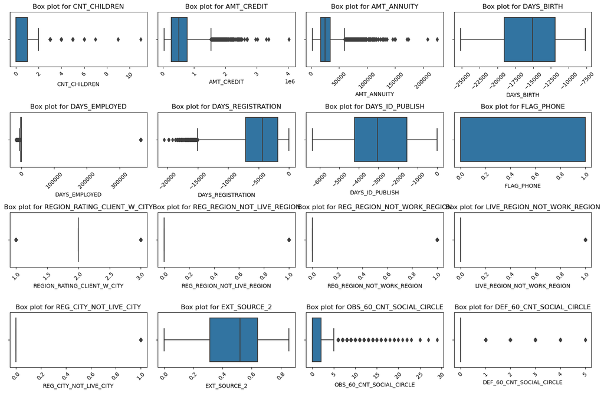

```python
# List of selected numerical columns
numerical_columns = [
    "CNT_CHILDREN", "AMT_CREDIT", "AMT_ANNUITY",
    "DAYS_BIRTH", "DAYS_EMPLOYED",
    "DAYS_REGISTRATION", "DAYS_ID_PUBLISH", "FLAG_PHONE",
    "REGION_RATING_CLIENT_W_CITY", "REG_REGION_NOT_LIVE_REGION",
    "REG_REGION_NOT_WORK_REGION", "LIVE_REGION_NOT_WORK_REGION",
    "REG_CITY_NOT_LIVE_CITY", "EXT_SOURCE_2",
    "OBS_60_CNT_SOCIAL_CIRCLE", "DEF_60_CNT_SOCIAL_CIRCLE"]

# Initialise an empty dictionary to store the results
outliers_dict = {}

for col in numerical_columns:
    Q1 = df_clean[col].quantile(0.25)
    Q3 = df_clean[col].quantile(0.75)
    IQR = Q3 - Q1

    lower_bound = Q1 - 1.5 * IQR
    upper_bound = Q3 + 1.5 * IQR

    # Get count of outliers below the lower bound
    outliers_below = df_clean[df_clean[col] < lower_bound].shape[0]

    # Get count of outliers above the upper bound
    outliers_above = df_clean[df_clean[col] > upper_bound].shape[0]

    # Store the results
    outliers_dict[col] = {
        "Lower_Bound": lower_bound,
        "Upper_Bound": upper_bound,
        "Outliers_Below": outliers_below,
        "Outliers_Above": outliers_above,
        "Total_Outliers": outliers_below + outliers_above
    }

# Convert the dictionary to a dataframe for better presentation
outliers_df = pd.DataFrame(outliers_dict).T

print(outliers_df)

# Box plots for visualizing median, quartiles, and possible outliers
fig, axes = plt.subplots(4, 4, figsize=(15, 10))
axes = axes.ravel()

for i, col in enumerate(numerical_columns):
    sns.boxplot(x=df_clean[col], ax=axes[i])
    axes[i].set_title(f'Box plot for {col}')
    axes[i].tick_params(axis='x', rotation=45)

plt.tight_layout()
plt.show()

# (So, 2023)
# (Dong, 2023)
# (OpenAI, 2023)
```

```python
# Handle outliers for continuous variables
continuous_cols = ['CNT_CHILDREN', 'AMT_CREDIT', 'AMT_ANNUITY']
for column in continuous_cols:
    # Cap outliers based on the provided upper and lower bounds
    lower_bound = df_clean[column].quantile(0.25) - 1.5 * (df_clean[column].quantile(0.75) - df_clean[column].quantile(0.25))
    upper_bound = df_clean[column].quantile(0.75) + 1.5 * (df_clean[column].quantile(0.75) - df_clean[column].quantile(0.25))
    df_clean[column] = np.where(df_clean[column] < lower_bound, lower_bound, df_clean[column])
    df_clean[column] = np.where(df_clean[column] > upper_bound, upper_bound, df_clean[column])

# (So, 2023)
# (OpenAI, 2023)
```

```python
# Correct false entries for the DAYS columns
days_columns = ['DAYS_BIRTH', 'DAYS_EMPLOYED', 'DAYS_REGISTRATION', 'DAYS_ID_PUBLISH']

for column in days_columns:
    # replace positive values with NaN
    df_clean.loc[df_clean[column] > 0, column] = np.nan

    # impute NaN values with the median of the negative values
    median_val = df_clean[df_clean[column] < 0][column].median()
    df_clean[column].fillna(median_val, inplace=True)

# (So, 2023)
# (OpenAI, 2023)
```

```
                               Lower_Bound   Upper_Bound  Outliers_Below  \
CNT_CHILDREN                     -1.500000  2.500000e+00             0.0
AMT_CREDIT                  -482186.250000  1.540384e+06             0.0
AMT_ANNUITY                   -9004.500000  6.000750e+04             0.0
DAYS_BIRTH                   -29758.000000 -1.174000e+03             0.0
DAYS_EMPLOYED                 -5058.500000  1.753500e+03          3225.0
DAYS_REGISTRATION            -15018.000000  6.054000e+03           136.0
DAYS_ID_PUBLISH               -8240.500000  2.459500e+03             0.0
FLAG_PHONE                       -1.500000  2.500000e+00             0.0
REGION_RATING_CLIENT_W_CITY       2.000000  2.000000e+00          3878.0
REG_REGION_NOT_LIVE_REGION        0.000000  0.000000e+00             0.0
REG_REGION_NOT_WORK_REGION        0.000000  0.000000e+00             0.0
LIVE_REGION_NOT_WORK_REGION       0.000000  0.000000e+00             0.0
REG_CITY_NOT_LIVE_CITY            0.000000  0.000000e+00             0.0
EXT_SOURCE_2                     -0.174008  1.125720e+00             0.0
OBS_60_CNT_SOCIAL_CIRCLE         -3.000000  5.000000e+00             0.0
DEF_60_CNT_SOCIAL_CIRCLE          0.000000  0.000000e+00             0.0

                             Outliers_Above  Total_Outliers
CNT_CHILDREN                            0.0             0.0
AMT_CREDIT                              0.0             0.0
AMT_ANNUITY                             0.0             0.0
DAYS_BIRTH                              0.0             0.0
DAYS_EMPLOYED                           0.0          3225.0
DAYS_REGISTRATION                       0.0           136.0
DAYS_ID_PUBLISH                         0.0             0.0
FLAG_PHONE                              0.0             0.0
REGION_RATING_CLIENT_W_CITY          7198.0         11076.0
REG_REGION_NOT_LIVE_REGION            692.0           692.0
REG_REGION_NOT_WORK_REGION           2245.0          2245.0
LIVE_REGION_NOT_WORK_REGION          1747.0          1747.0
REG_CITY_NOT_LIVE_CITY               4118.0          4118.0
EXT_SOURCE_2                            0.0             0.0
OBS_60_CNT_SOCIAL_CIRCLE             2833.0          2833.0
DEF_60_CNT_SOCIAL_CIRCLE             4119.0          4119.0
```

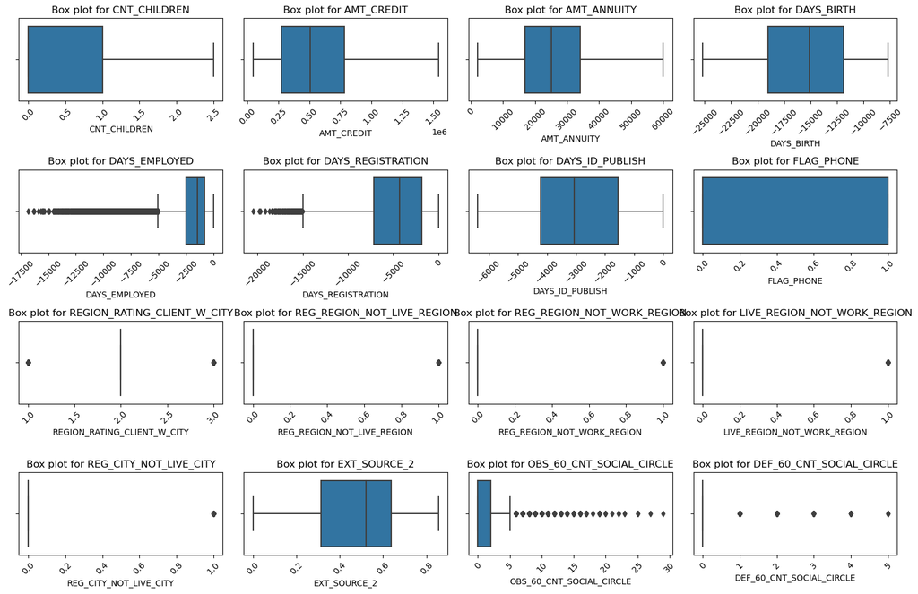

```python
# Initialise an empty dictionary to store the results
outliers_dict = {}

for col in numerical_columns:
    Q1 = df_clean[col].quantile(0.25)
    Q3 = df_clean[col].quantile(0.75)
    IQR = Q3 - Q1

    lower_bound = Q1 - 1.5 * IQR
    upper_bound = Q3 + 1.5 * IQR

    # Get count of outliers below the lower bound
    outliers_below = df_clean[df_clean[col] < lower_bound].shape[0]

    # Get count of outliers above the upper bound
    outliers_above = df_clean[df_clean[col] > upper_bound].shape[0]

    # Store the results
    outliers_dict[col] = {
        "Lower_Bound": lower_bound,
        "Upper_Bound": upper_bound,
        "Outliers_Below": outliers_below,
        "Outliers_Above": outliers_above,
        "Total_Outliers": outliers_below + outliers_above
    }

# Convert the dictionary to a dataframe for better presentation
outliers_df = pd.DataFrame(outliers_dict).T

print(outliers_df)

# Box plots for visualizing median, quartiles, and possible outliers
fig, axes = plt.subplots(4, 4, figsize=(15, 10))
axes = axes.ravel()

for i, col in enumerate(numerical_columns):
    sns.boxplot(x=df_clean[col], ax=axes[i])
    axes[i].set_title(f'Box plot for {col}')
    axes[i].tick_params(axis='x', rotation=45)

plt.tight_layout()
plt.show()
# (So, 2023)
```

```python
df_clean.info()
```

```
<class 'pandas.core.frame.DataFrame'>
RangeIndex: 42452 entries, 0 to 42451
Data columns (total 27 columns):
 #   Column                       Non-Null Count  Dtype
---  ------                       --------------  -----
 0   TARGET                       42452 non-null  int64
 1   NAME_CONTRACT_TYPE           42452 non-null  category
 2   CODE_GENDER                  42452 non-null  category
 3   FLAG_OWN_CAR                 42452 non-null  category
 4   FLAG_OWN_REALTY              42452 non-null  category
 5   CNT_CHILDREN                 42452 non-null  float64
 6   AMT_CREDIT                   42452 non-null  float64
 7   AMT_ANNUITY                  42452 non-null  float64
 8   NAME_INCOME_TYPE             42452 non-null  object
 9   NAME_EDUCATION_TYPE          42452 non-null  object
```

[output cut: 19 more lines]

```python
df_clean.head()
```

|  | TARGET | NAME_CONTRACT_TYPE | CODE_GENDER | FLAG_OWN_CAR | FLAG_OWN_REALTY | CNT_CHILDREN | AMT_CREDIT | AMT_ANNUITY | NAME_INCOME_TYPE | NAME_EDUCATION_TYPE | NAME_FAMILY_STATUS | NAME_HOUSING_TYPE | DAYS_BIRTH | DAYS_EMPLOYED | DAYS_REGISTRATION | DAYS_ID_PUBLISH | FLAG_PHONE | REGION_RATING_CLIENT_W_CITY | REG_REGION_NOT_LIVE_REGION | REG_REGION_NOT_WORK_REGION | LIVE_REGION_NOT_WORK_REGION | REG_CITY_NOT_LIVE_CITY | ORGANIZATION_TYPE | EXT_SOURCE_2 | OBS_60_CNT_SOCIAL_CIRCLE | DEF_60_CNT_SOCIAL_CIRCLE | SK_ID_CURR |
| --- | --- | --- | --- | --- | --- | --- | --- | --- | --- | --- | --- | --- | --- | --- | --- | --- | --- | --- | --- | --- | --- | --- | --- | --- | --- | --- | --- |
| 0 | 1 | Cash loans | M | N | Y | 0.0 | 406597.5 | 24700.5 | Working | Secondary / secondary special | Single / not married | House / apartment | -9461.0 | -637.0 | -3648.0 | -2120.0 | 1 | 2 | 0 | 0 | 0 | 0 | Business Entity Type 3 | 0.262949 | 2.0 | 2.0 | 100002 |
| 1 | 1 | Cash loans | F | N | Y | 0.0 | 979992.0 | 27076.5 | Working | Secondary / secondary special | Widow | House / apartment | -18724.0 | -2628.0 | -6573.0 | -1827.0 | 0 | 2 | 0 | 0 | 0 | 0 | Business Entity Type 3 | 0.548477 | 10.0 | 0.0 | 100031 |
| 2 | 1 | Cash loans | M | N | Y | 0.0 | 1193580.0 | 35028.0 | Commercial associate | Secondary / secondary special | Married | House / apartment | -17482.0 | -1262.0 | -1182.0 | -1029.0 | 0 | 2 | 0 | 0 | 0 | 0 | Business Entity Type 3 | 0.306841 | 0.0 | 0.0 | 100047 |
| 3 | 1 | Cash loans | F | N | N | 0.0 | 288873.0 | 16258.5 | Working | Secondary / secondary special | Civil marriage | House / apartment | -13384.0 | -3597.0 | -45.0 | -4409.0 | 1 | 3 | 0 | 0 | 0 | 0 | Self-employed | 0.674203 | 1.0 | 0.0 | 100049 |
| 4 | 1 | Cash loans | M | Y | Y | 0.0 | 953460.0 | 60007.5 | Commercial associate | Incomplete higher | Single / not married | With parents | -10199.0 | -2015.0 | -4802.0 | -1038.0 | 0 | 2 | 0 | 0 | 0 | 0 | Industry: type 4 | 0.432340 | 0.0 | 0.0 | 100112 |

### Step 2.3 - Format data

```python
from sklearn.preprocessing import LabelEncoder

# Handling Categorical Data:

# Label Encoding for binary categorical variables
label_cols = ['NAME_CONTRACT_TYPE', 'CODE_GENDER', 'FLAG_OWN_CAR', 'FLAG_OWN_REALTY']
label_encoder = LabelEncoder()

for col in label_cols:
    df_clean[col] = label_encoder.fit_transform(df_clean[col])

# One-Hot Encoding for non-binary categorical variables
# For organization type
N = 10

# Step 1: Identify the top N most frequent organization types
top_N_org_types = df_clean['ORGANIZATION_TYPE'].value_counts().index[:N].tolist()

# Step 2: Replace less frequent organization types with 'Other' and overwrite the original column
df_clean['ORGANIZATION_TYPE'] = df_clean['ORGANIZATION_TYPE'].apply(lambda x: x if x in top_N_org_types else 'Other')

onehot_cols = ['NAME_INCOME_TYPE', 'NAME_EDUCATION_TYPE', 'NAME_FAMILY_STATUS', 'NAME_HOUSING_TYPE', 'ORGANIZATION_TYPE']
df_clean = pd.get_dummies(df_clean, columns=onehot_cols)

# (GeeksforGeeks, 2023)
# (OpenAI, 2023)
```

```python
# Convert Days to Years:

# Converting the columns in days to columns in years
df_clean['DAYS_BIRTH'] = df_clean['DAYS_BIRTH'] / -365
df_clean['DAYS_EMPLOYED'] = df_clean['DAYS_EMPLOYED'] / -365
df_clean['DAYS_REGISTRATION'] = df_clean['DAYS_REGISTRATION'] / -365
df_clean['DAYS_ID_PUBLISH'] = df_clean['DAYS_ID_PUBLISH'] / -365

# Renaming columns for clarity
df_clean.rename(columns={'DAYS_BIRTH': 'AGE_YEARS', 'DAYS_EMPLOYED': 'YEARS_EMPLOYED', 'DAYS_REGISTRATION': 'YEARS_REGISTRATION', 'DAYS_ID_PUBLISH': 'YEARS_ID_PUBLISH'}, inplace=True)
# (So, 2023)
```

```python
df_clean.info()
```

```
<class 'pandas.core.frame.DataFrame'>
RangeIndex: 42452 entries, 0 to 42451
Data columns (total 56 columns):
 #   Column                                             Non-Null Count  Dtype
---  ------                                             --------------  -----
 0   TARGET                                             42452 non-null  int64
 1   NAME_CONTRACT_TYPE                                 42452 non-null  int32
 2   CODE_GENDER                                        42452 non-null  int32
 3   FLAG_OWN_CAR                                       42452 non-null  int32
 4   FLAG_OWN_REALTY                                    42452 non-null  int32
 5   CNT_CHILDREN                                       42452 non-null  float64
 6   AMT_CREDIT                                         42452 non-null  float64
 7   AMT_ANNUITY                                        42452 non-null  float64
 8   AGE_YEARS                                          42452 non-null  float64
 9   YEARS_EMPLOYED                                     42452 non-null  float64
```

[output cut: 48 more lines]

### Step 2.4 - Split data

```python
from sklearn.model_selection import train_test_split

# Splitting the data
X = df_clean.drop(columns=['TARGET'])  # excluding the target variable
y = df_clean['TARGET']

X_train, X_test, y_train, y_test = train_test_split(X, y, test_size=0.25, random_state=42)  # 75% training and 25% test

# Print the shape of train and test sets to verify
print(f"X_train shape: {X_train.shape}")
print(f"y_train shape: {y_train.shape}")
print(f"X_test shape: {X_test.shape}")
print(f"y_test shape: {y_test.shape}")
# (So, 2023)
```

```
X_train shape: (31839, 55)
y_train shape: (31839,)
X_test shape: (10613, 55)
y_test shape: (10613,)
```

# Step 3: Modeling

- Select modeling techniques
- Generate test design
- Build model
- Assess model

(Hotz, 2023)

### 3.1 Create baseline model

```python
from scipy.stats import mode
from sklearn.metrics import accuracy_score, classification_report, confusion_matrix

# Predict the mode of the target variable for all the samples
y_pred_mode = [mode(y_train)[0][0]] * len(y_test)

# Evaluate the model using the mode prediction
accuracy_mode = accuracy_score(y_test, y_pred_mode)
print(f"Accuracy of Baseline Model using Mode: {accuracy_mode:.2f}")

print("\nClassification Report:")
print(classification_report(y_test, y_pred_mode))

print("\nConfusion Matrix:")
print(confusion_matrix(y_test, y_pred_mode))

# (So, 2023)
```

```
Accuracy of Baseline Model using Mode: 0.53

Classification Report:
              precision    recall  f1-score   support

           0       0.53      1.00      0.69      5601
           1       0.00      0.00      0.00      5012

    accuracy                           0.53     10613
   macro avg       0.26      0.50      0.35     10613
weighted avg       0.28      0.53      0.36     10613


Confusion Matrix:
[[5601    0]
 [5012    0]]
```

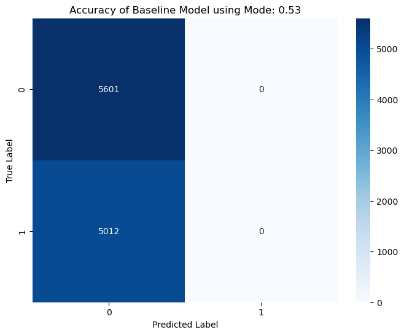

```python
# Confusion Matrix Visualization
cm = confusion_matrix(y_test, y_pred_mode)

plt.figure(figsize=(8, 6))
sns.heatmap(cm, annot=True, fmt="d", cmap="Blues")
plt.title(f"Accuracy of Baseline Model using Mode: {accuracy_mode:.2f}")
plt.xlabel("Predicted Label")
plt.ylabel("True Label")
plt.show()

# (So, 2023)
```

### 3.2 Experiment 1: K-Nearest Neighbors

```python
from sklearn.neighbors import KNeighborsClassifier

# 1. Initialize and train the default KNN model
knn_default = KNeighborsClassifier()
knn_default.fit(X_train, y_train)
y_pred_default = knn_default.predict(X_test)

# 2. Evaluate the default model
accuracy_default = accuracy_score(y_test, y_pred_default)
print(f"Accuracy of Default KNN Model: {accuracy_default:.2f}")

print("\nClassification Report:")
print(classification_report(y_test, y_pred_default))
print("\nConfusion Matrix:")
print(confusion_matrix(y_test, y_pred_default))

# (So, 2023)
# (OpenAI, 2023)
```

```
Accuracy of Default KNN Model: 0.53

Classification Report:
              precision    recall  f1-score   support

           0       0.55      0.58      0.56      5601
           1       0.50      0.48      0.49      5012

    accuracy                           0.53     10613
   macro avg       0.53      0.53      0.53     10613
weighted avg       0.53      0.53      0.53     10613


Confusion Matrix:
[[3225 2376]
 [2596 2416]]
```

```python
from sklearn.model_selection import GridSearchCV

# 3. Hyperparameter tuning with GridSearchCV
param_grid = {
    'n_neighbors': [3, 5, 7],
    'weights': ['uniform'],
    'metric': ['euclidean']
}

knn_grid = KNeighborsClassifier()
grid_search = GridSearchCV(knn_grid, param_grid, cv=3, scoring='accuracy', n_jobs=-1)
grid_search.fit(X_train, y_train)

print("Best Hyperparameters:", grid_search.best_params_)

# 4. Train and evaluate the optimized model
knn_optimized = KNeighborsClassifier(**grid_search.best_params_)
knn_optimized.fit(X_train, y_train)
y_pred_optimized = knn_optimized.predict(X_test)

accuracy_optimized = accuracy_score(y_test, y_pred_optimized)
print(f"Accuracy of Optimized KNN Model: {accuracy_optimized:.2f}")

print("\nClassification Report:")
print(classification_report(y_test, y_pred_optimized))
print("\nConfusion Matrix:")
print(confusion_matrix(y_test, y_pred_optimized))

# (Brownlee, 2020)
# (Shafi, 2023)
# (Sklearn.Neighbors.KNeighborsClassifier, n.d.)
# (So, 2023)
# (OpenAI, 2023)
```

```
Best Hyperparameters: {'metric': 'euclidean', 'n_neighbors': 7, 'weights': 'uniform'}
Accuracy of Optimized KNN Model: 0.53

Classification Report:
              precision    recall  f1-score   support

           0       0.56      0.58      0.57      5601
           1       0.51      0.49      0.50      5012

    accuracy                           0.53     10613
   macro avg       0.53      0.53      0.53     10613
weighted avg       0.53      0.53      0.53     10613


Confusion Matrix:
[[3244 2357]
 [2580 2432]]
```

```python
from sklearn.model_selection import StratifiedKFold, cross_val_score

# 5. Cross-validation with StratifiedKFold
stratified_kfold = StratifiedKFold(n_splits=10, shuffle=True, random_state=42)
cross_val_accuracies = cross_val_score(knn_optimized, X_train, y_train, cv=stratified_kfold, scoring='accuracy', n_jobs=-1)

print(f"Cross-Validation Accuracies: {cross_val_accuracies}")
print(f"Mean Accuracy: {cross_val_accuracies.mean():.2f}")
print(f"Standard Deviation: {cross_val_accuracies.std():.2f}")

# 6. Final evaluation on the test set
knn_optimized.fit(X_train, y_train)
y_pred_cross_val = knn_optimized.predict(X_test)

accuracy_cross_val = accuracy_score(y_test, y_pred_cross_val)
print(f"\nAccuracy of KNN Model with Stratified K-Fold CV: {accuracy_cross_val:.2f}")

print("\nClassification Report:")
print(classification_report(y_test, y_pred_cross_val))
print("\nConfusion Matrix:")
print(confusion_matrix(y_test, y_pred_cross_val))

# (Explain Stratified K Fold Cross Validation in ML in Python, 2022)
# (Sklearn.Model_Selection.StratifiedKFold, n.d.)
# (So, 2023)
# (OpenAI, 2023)
```

```
Cross-Validation Accuracies: [0.5285804  0.52732412 0.54522613 0.52952261 0.53988693 0.53015075
 0.55527638 0.54082915 0.54993719 0.52968897]
Mean Accuracy: 0.54
Standard Deviation: 0.01

Accuracy of KNN Model with Stratified K-Fold CV: 0.53

Classification Report:
              precision    recall  f1-score   support

           0       0.56      0.58      0.57      5601
           1       0.51      0.49      0.50      5012

    accuracy                           0.53     10613
   macro avg       0.53      0.53      0.53     10613
weighted avg       0.53      0.53      0.53     10613


Confusion Matrix:
[[3244 2357]
 [2580 2432]]
```

### 3.3 Experiment 2: Support Vector Machine

```python
from sklearn.svm import SVC

# 1. Initialize and train the default SVM model
svm_default = SVC()
svm_default.fit(X_train, y_train)
y_pred_svm = svm_default.predict(X_test)

# 2. Evaluate the default model
accuracy_svm = accuracy_score(y_test, y_pred_svm)
print(f"Accuracy of Default SVM Model: {accuracy_svm:.2f}")

print("\nClassification Report:")
print(classification_report(y_test, y_pred_svm))
print("\nConfusion Matrix:")
print(confusion_matrix(y_test, y_pred_svm))
# (So, 2023)
# (OpenAI, 2023)
```

```
Accuracy of Default SVM Model: 0.55

Classification Report:
              precision    recall  f1-score   support

           0       0.58      0.55      0.56      5601
           1       0.52      0.55      0.53      5012

    accuracy                           0.55     10613
   macro avg       0.55      0.55      0.55     10613
weighted avg       0.55      0.55      0.55     10613


Confusion Matrix:
[[3083 2518]
 [2277 2735]]
```

```python
# 3. Hyperparameter tuning with GridSearchCV
param_grid_svm = {
    'C': [0.1, 1, 10]
}

svm_grid = SVC()
grid_search_svm = GridSearchCV(svm_grid, param_grid_svm, cv=3, scoring='accuracy', n_jobs=-1)
grid_search_svm.fit(X_train, y_train)

print("Best Hyperparameters:", grid_search_svm.best_params_)

# 4. Train and evaluate the optimized model
best_svm = SVC(**grid_search_svm.best_params_)
best_svm.fit(X_train, y_train)
y_pred_svm_optimized = best_svm.predict(X_test)

accuracy_svm_optimized = accuracy_score(y_test, y_pred_svm_optimized)
print(f"Accuracy of Optimized SVM Model: {accuracy_svm_optimized:.2f}")

print("\nClassification Report:")
print(classification_report(y_test, y_pred_svm_optimized))
print("\nConfusion Matrix:")
print(confusion_matrix(y_test, y_pred_svm_optimized))

# (So, 2023)
# (Sklearn.svm.SVC, n.d.)
# (OpenAI, 2023)
# (Yıldırım, 2021)
```

```
Best Hyperparameters: {'C': 10}
Accuracy of Optimized SVM Model: 0.55

Classification Report:
              precision    recall  f1-score   support

           0       0.57      0.62      0.59      5601
           1       0.53      0.47      0.50      5012

    accuracy                           0.55     10613
   macro avg       0.55      0.55      0.55     10613
weighted avg       0.55      0.55      0.55     10613


Confusion Matrix:
[[3485 2116]
 [2647 2365]]
```

```python
# 5. Cross-validation with StratifiedKFold
stratified_kfold_svm = StratifiedKFold(n_splits=10, shuffle=True, random_state=42)
cross_val_accuracies_svm = cross_val_score(best_svm, X_train, y_train, cv=stratified_kfold_svm, scoring='accuracy', n_jobs=-1)

print(f"Cross-Validation Accuracies (SVM): {cross_val_accuracies_svm}")
print(f"Mean Accuracy (SVM): {cross_val_accuracies_svm.mean():.2f}")
print(f"Standard Deviation (SVM): {cross_val_accuracies_svm.std():.2f}")

# 6. Final evaluation on the test set
best_svm.fit(X_train, y_train)
y_pred_svm_cross_val = best_svm.predict(X_test)

accuracy_svm_cross_val = accuracy_score(y_test, y_pred_svm_cross_val)
print(f"\nAccuracy of SVM Model with Stratified K-Fold CV: {accuracy_svm_cross_val:.2f}")

print("\nClassification Report (SVM):")
print(classification_report(y_test, y_pred_svm_cross_val))
print("\nConfusion Matrix (SVM):")
print(confusion_matrix(y_test, y_pred_svm_cross_val))

# (Explain Stratified K Fold Cross Validation in ML in Python, 2022)
# (Sklearn.Model_Selection.StratifiedKFold, n.d.)
# (So, 2023)
# (OpenAI, 2023)
```

```
Cross-Validation Accuracies (SVM): [0.55056533 0.54773869 0.55150754 0.54648241 0.54271357 0.54302764
 0.54271357 0.53454774 0.55307789 0.54131323]
Mean Accuracy (SVM): 0.55
Standard Deviation (SVM): 0.01

Accuracy of SVM Model with Stratified K-Fold CV: 0.55

Classification Report (SVM):
              precision    recall  f1-score   support

           0       0.57      0.62      0.59      5601
           1       0.53      0.47      0.50      5012

    accuracy                           0.55     10613
   macro avg       0.55      0.55      0.55     10613
weighted avg       0.55      0.55      0.55     10613


Confusion Matrix (SVM):
[[3485 2116]
 [2647 2365]]
```

### 3.4 Experiment 3: Decision Tree

```python
from sklearn.tree import DecisionTreeClassifier
# 1. Initialize and train the default Decision Tree model
dt_default = DecisionTreeClassifier(random_state=42)
dt_default.fit(X_train, y_train)
y_pred_default = dt_default.predict(X_test)

# 2. Evaluate the default model
accuracy_default = accuracy_score(y_test, y_pred_default)
print(f"Accuracy of Default Decision Tree Model: {accuracy_default:.2f}")

print("\nClassification Report:")
print(classification_report(y_test, y_pred_default))
print("\nConfusion Matrix:")
print(confusion_matrix(y_test, y_pred_default))

# (So, 2023)
# (OpenAI, 2023)
```

```
Accuracy of Default Decision Tree Model: 0.56

Classification Report:
              precision    recall  f1-score   support

           0       0.59      0.58      0.58      5601
           1       0.54      0.54      0.54      5012

    accuracy                           0.56     10613
   macro avg       0.56      0.56      0.56     10613
weighted avg       0.56      0.56      0.56     10613


Confusion Matrix:
[[3266 2335]
 [2315 2697]]
```

```python
# 3. Hyperparameter tuning with GridSearchCV
param_grid_dt = {
    'criterion': ['gini', 'entropy'],
    'max_depth': [None, 5, 10, 15],
    'min_samples_split': [2, 5],
    'min_samples_leaf': [1, 2, 4]
}

grid_search_dt = GridSearchCV(DecisionTreeClassifier(random_state=42), param_grid_dt, cv=5, scoring='accuracy', n_jobs=-1)
grid_search_dt.fit(X_train, y_train)

print("Best Hyperparameters for Decision Tree:")
print(grid_search_dt.best_params_)

# 4. Train and evaluate the optimized model
best_dt = DecisionTreeClassifier(**grid_search_dt.best_params_, random_state=42)
best_dt.fit(X_train, y_train)
y_pred_grid = best_dt.predict(X_test)

accuracy_grid = accuracy_score(y_test, y_pred_grid)
print(f"\nAccuracy of Decision Tree with Best Hyperparameters: {accuracy_grid:.2f}")

print("\nClassification Report:")
print(classification_report(y_test, y_pred_grid))
print("\nConfusion Matrix:")
print(confusion_matrix(y_test, y_pred_grid))

# (Mithrakumar, 2021)
# (Sklearn.tree.DecisionTreeClassifier, n.d.)
# (So, 2023)
# (OpenAI, 2023)
```

```
Best Hyperparameters for Decision Tree:
{'criterion': 'gini', 'max_depth': 5, 'min_samples_leaf': 1, 'min_samples_split': 2}

Accuracy of Decision Tree with Best Hyperparameters: 0.63

Classification Report:
              precision    recall  f1-score   support

           0       0.62      0.73      0.67      5601
           1       0.63      0.51      0.56      5012

    accuracy                           0.63     10613
   macro avg       0.63      0.62      0.62     10613
weighted avg       0.63      0.63      0.62     10613


Confusion Matrix:
[[4099 1502]
 [2475 2537]]
```

```python
# 5. Cross-validation with StratifiedKFold
stratified_kfold_dt = StratifiedKFold(n_splits=10, shuffle=True, random_state=42)
cross_val_accuracies_dt = cross_val_score(best_dt, X_train, y_train, cv=stratified_kfold_dt, scoring='accuracy', n_jobs=-1)

print(f"Cross-Validation Accuracies (Decision Tree): {cross_val_accuracies_dt}")
print(f"Mean Accuracy (Decision Tree): {cross_val_accuracies_dt.mean():.2f}")
print(f"Standard Deviation (Decision Tree): {cross_val_accuracies_dt.std():.2f}")

# 6. Final evaluation on the test set
best_dt.fit(X_train, y_train)
y_pred_dt_cross_val = best_dt.predict(X_test)

accuracy_dt_cross_val = accuracy_score(y_test, y_pred_dt_cross_val)
print(f"\nAccuracy of Decision Tree Model with Stratified K-Fold CV: {accuracy_dt_cross_val:.2f}")

print("\nClassification Report (Decision Tree):")
print(classification_report(y_test, y_pred_dt_cross_val))
print("\nConfusion Matrix (Decision Tree):")
print(confusion_matrix(y_test, y_pred_dt_cross_val))

# (Explain Stratified K Fold Cross Validation in ML in Python, 2022)
# (Sklearn.Model_Selection.StratifiedKFold, n.d.)
# (So, 2023)
# (OpenAI, 2023)
```

```
Cross-Validation Accuracies (Decision Tree): [0.62688442 0.625      0.63505025 0.63505025 0.63442211 0.61055276
 0.64572864 0.63316583 0.63128141 0.62519636]
Mean Accuracy (Decision Tree): 0.63
Standard Deviation (Decision Tree): 0.01

Accuracy of Decision Tree Model with Stratified K-Fold CV: 0.63

Classification Report (Decision Tree):
              precision    recall  f1-score   support

           0       0.62      0.73      0.67      5601
           1       0.63      0.51      0.56      5012

    accuracy                           0.63     10613
   macro avg       0.63      0.62      0.62     10613
weighted avg       0.63      0.63      0.62     10613


Confusion Matrix (Decision Tree):
[[4099 1502]
 [2475 2537]]
```

### 3.5 Experiment 4: Random Forest

```python
from sklearn.ensemble import RandomForestClassifier

# 1. Initialize and train the default Random Forest model
rf_default = RandomForestClassifier(random_state=42)
rf_default.fit(X_train, y_train)
y_pred_default_rf = rf_default.predict(X_test)

# 2. Evaluate the default model
accuracy_default_rf = accuracy_score(y_test, y_pred_default_rf)
print(f"Accuracy of Default Random Forest Model: {accuracy_default_rf:.2f}")

print("\nClassification Report:")
print(classification_report(y_test, y_pred_default_rf))
print("\nConfusion Matrix:")
print(confusion_matrix(y_test, y_pred_default_rf))

# (So, 2023)
# (OpenAI, 2023)
```

```
Accuracy of Default Random Forest Model: 0.64

Classification Report:
              precision    recall  f1-score   support

           0       0.65      0.71      0.68      5601
           1       0.63      0.57      0.60      5012

    accuracy                           0.64     10613
   macro avg       0.64      0.64      0.64     10613
weighted avg       0.64      0.64      0.64     10613


Confusion Matrix:
[[3964 1637]
 [2176 2836]]
```

```python
# 3. Hyperparameter tuning with GridSearchCV
param_grid_rf = {
    'n_estimators': [10, 50],
    'max_depth': [None, 5, 10],
    'min_samples_split': [2, 5],
    'min_samples_leaf': [1, 2]
}

grid_search_rf = GridSearchCV(RandomForestClassifier(random_state=42), param_grid_rf, cv=5, scoring='accuracy', n_jobs=-1)
grid_search_rf.fit(X_train, y_train)

print("Best Hyperparameters for Random Forest:")
print(grid_search_rf.best_params_)

# 4. Train and evaluate the optimized model
best_rf = RandomForestClassifier(**grid_search_rf.best_params_, random_state=42)
best_rf.fit(X_train, y_train)
y_pred_grid_rf = best_rf.predict(X_test)

accuracy_grid_rf = accuracy_score(y_test, y_pred_grid_rf)
print(f"\nAccuracy of Random Forest with Best Hyperparameters: {accuracy_grid_rf:.2f}")

print("\nClassification Report:")
print(classification_report(y_test, y_pred_grid_rf))
print("\nConfusion Matrix:")
print(confusion_matrix(y_test, y_pred_grid_rf))

# (Koehrsen, 2019)
# (Sklearn.Ensemble.RandomForestClassifier, n.d.)
# (So, 2023)
# (OpenAI, 2023)
```

```
Best Hyperparameters for Random Forest:
{'max_depth': 10, 'min_samples_leaf': 1, 'min_samples_split': 2, 'n_estimators': 50}

Accuracy of Random Forest with Best Hyperparameters: 0.65

Classification Report:
              precision    recall  f1-score   support

           0       0.65      0.72      0.68      5601
           1       0.64      0.56      0.60      5012

    accuracy                           0.65     10613
   macro avg       0.64      0.64      0.64     10613
weighted avg       0.64      0.65      0.64     10613


Confusion Matrix:
[[4020 1581]
 [2183 2829]]
```

```python
# 5. Cross-validation with StratifiedKFold
stratified_kfold_rf = StratifiedKFold(n_splits=10, shuffle=True, random_state=42)
cross_val_accuracies_rf = cross_val_score(best_rf, X_train, y_train, cv=stratified_kfold_rf, scoring='accuracy', n_jobs=-1)

print(f"Cross-Validation Accuracies (Random Forest): {cross_val_accuracies_rf}")
print(f"Mean Accuracy (Random Forest): {cross_val_accuracies_rf.mean():.2f}")
print(f"Standard Deviation (Random Forest): {cross_val_accuracies_rf.std():.2f}")

# 6. Final evaluation on the test set
best_rf.fit(X_train, y_train)
y_pred_rf_cross_val = best_rf.predict(X_test)

accuracy_rf_cross_val = accuracy_score(y_test, y_pred_rf_cross_val)
print(f"\nAccuracy of Random Forest Model with Stratified K-Fold CV: {accuracy_rf_cross_val:.2f}")

print("\nClassification Report (Random Forest):")
print(classification_report(y_test, y_pred_rf_cross_val))
print("\nConfusion Matrix (Random Forest):")
print(confusion_matrix(y_test, y_pred_rf_cross_val))

# (Explain Stratified K Fold Cross Validation in ML in Python, 2022)
# (Sklearn.Model_Selection.StratifiedKFold, n.d.)
# (So, 2023)
# (OpenAI, 2023)
```

```
Cross-Validation Accuracies (Random Forest): [0.64949749 0.64855528 0.6589196  0.65483668 0.66582915 0.6388191
 0.66551508 0.64761307 0.64855528 0.63713478]
Mean Accuracy (Random Forest): 0.65
Standard Deviation (Random Forest): 0.01

Accuracy of Random Forest Model with Stratified K-Fold CV: 0.65

Classification Report (Random Forest):
              precision    recall  f1-score   support

           0       0.65      0.72      0.68      5601
           1       0.64      0.56      0.60      5012

    accuracy                           0.65     10613
   macro avg       0.64      0.64      0.64     10613
weighted avg       0.64      0.65      0.64     10613


Confusion Matrix (Random Forest):
[[4020 1581]
 [2183 2829]]
```

```
                                              Feature  Importance
17                                       EXT_SOURCE_2    0.286130
7                                           AGE_YEARS    0.096478
8                                      YEARS_EMPLOYED    0.082321
5                                          AMT_CREDIT    0.055336
10                                   YEARS_ID_PUBLISH    0.052259
9                                  YEARS_REGISTRATION    0.050526
6                                         AMT_ANNUITY    0.047131
20                                         SK_ID_CURR    0.039358
29               NAME_EDUCATION_TYPE_Higher education    0.028072
32  NAME_EDUCATION_TYPE_Secondary / secondary special    0.023700
1                                         CODE_GENDER    0.021692
12                        REGION_RATING_CLIENT_W_CITY    0.019947
18                           OBS_60_CNT_SOCIAL_CIRCLE    0.016785
27                           NAME_INCOME_TYPE_Working    0.015717
```

[output cut: 41 more lines]

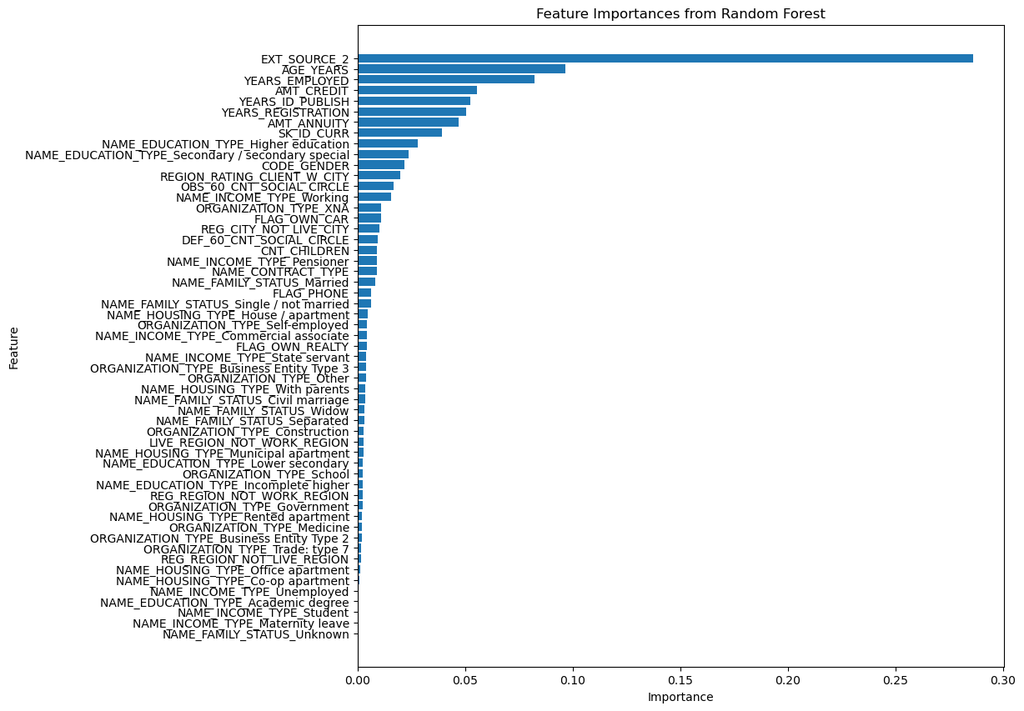

```python
feature_importances = best_rf.feature_importances_

# Create a DataFrame to display feature importances
features_df = pd.DataFrame({
    'Feature': X_train.columns,
    'Importance': feature_importances
})

# Sort the DataFrame by importance
features_df = features_df.sort_values(by='Importance', ascending=False)

# Display
print(features_df)

# Visualisation
plt.figure(figsize=(10, 10))
plt.barh(features_df['Feature'], features_df['Importance'])
plt.xlabel('Importance')
plt.ylabel('Feature')
plt.title('Feature Importances from Random Forest')
plt.gca().invert_yaxis()  # To display the most important feature at the top
plt.show()

# (So, 2023)
# (OpenAI, 2023)
```

# Step 4: Evaluation

- Evaluate results
- Review process
- Determine next steps

(Hotz, 2023)

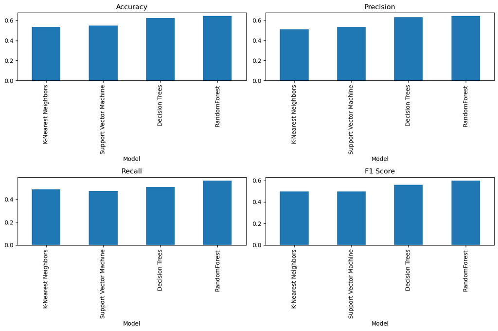

```
                        Accuracy  Precision    Recall        F1
Model
K-Nearest Neighbors     0.534816   0.507830  0.485235  0.496276
Support Vector Machine  0.551211   0.527784  0.471868  0.498262
Decision Trees          0.625271   0.628126  0.506185  0.560601
RandomForest            0.645341   0.641497  0.564445  0.600509
```

```python
from sklearn.metrics import precision_score, recall_score, f1_score

# KNN metrics
accuracy_knn = accuracy_cross_val
precision_knn = precision_score(y_test, y_pred_cross_val)
recall_knn = recall_score(y_test, y_pred_cross_val)
f1_knn = f1_score(y_test, y_pred_cross_val)

# SVM metrics
accuracy_svm = accuracy_svm_cross_val
precision_svm = precision_score(y_test, y_pred_svm_cross_val)
recall_svm = recall_score(y_test, y_pred_svm_cross_val)
f1_svm = f1_score(y_test, y_pred_svm_cross_val)

# Decision Tree metrics
accuracy_dt = accuracy_dt_cross_val
precision_dt = precision_score(y_test, y_pred_dt_cross_val)
recall_dt = recall_score(y_test, y_pred_dt_cross_val)
f1_dt = f1_score(y_test, y_pred_dt_cross_val)

# Random Forest metrics
accuracy_rf = accuracy_rf_cross_val
precision_rf = precision_score(y_test, y_pred_rf_cross_val)
recall_rf = recall_score(y_test, y_pred_rf_cross_val)
f1_rf = f1_score(y_test, y_pred_rf_cross_val)

# Create a DataFrame with the metrics for each model
results = pd.DataFrame({
    'Model': ['K-Nearest Neighbors', 'Support Vector Machine', 'Decision Trees', 'RandomForest'],
    'Accuracy': [accuracy_knn, accuracy_svm, accuracy_dt, accuracy_rf],
    'Precision': [precision_knn, precision_svm, precision_dt, precision_rf],
    'Recall': [recall_knn, recall_svm, recall_dt, recall_rf],
    'F1': [f1_knn, f1_svm, f1_dt, f1_rf]
})

# Set the index to the model name
results.set_index('Model', inplace=True)

# Create bar plots for each metric
fig, axes = plt.subplots(nrows=2, ncols=2, figsize=(12, 8))

results['Accuracy'].plot(kind='bar', ax=axes[0, 0], title='Accuracy')
results['Precision'].plot(kind='bar', ax=axes[0, 1], title='Precision')
results['Recall'].plot(kind='bar', ax=axes[1, 0], title='Recall')
results['F1'].plot(kind='bar', ax=axes[1, 1], title='F1 Score')

# Add space between subplots
plt.tight_layout()

# Display the plots
plt.show()

# Print the results table
print(results)

# (So, 2023)
# (OpenAI, 2023)
```

```python
sorted_results = results.sort_values(by='Accuracy', ascending=False)
print(sorted_results)
# (So, 2023)
```

```
                        Accuracy  Precision    Recall        F1
Model
RandomForest            0.645341   0.641497  0.564445  0.600509
Decision Trees          0.625271   0.628126  0.506185  0.560601
Support Vector Machine  0.551211   0.527784  0.471868  0.498262
K-Nearest Neighbors     0.534816   0.507830  0.485235  0.496276
```

# Step 5: Prediction on Unknown dataset

```python
# Create a copy of the dataframe with chosen features

selected_features = [
    "NAME_CONTRACT_TYPE", "CODE_GENDER", "FLAG_OWN_CAR",
    "FLAG_OWN_REALTY", "CNT_CHILDREN", "AMT_CREDIT", "AMT_ANNUITY",
    "NAME_INCOME_TYPE", "NAME_EDUCATION_TYPE",
    "NAME_FAMILY_STATUS", "NAME_HOUSING_TYPE", "DAYS_BIRTH", "DAYS_EMPLOYED",
    "DAYS_REGISTRATION", "DAYS_ID_PUBLISH", "FLAG_PHONE",
    "REGION_RATING_CLIENT_W_CITY", "REG_REGION_NOT_LIVE_REGION",
    "REG_REGION_NOT_WORK_REGION", "LIVE_REGION_NOT_WORK_REGION",
    "REG_CITY_NOT_LIVE_CITY", "ORGANIZATION_TYPE", "EXT_SOURCE_2",
    "OBS_60_CNT_SOCIAL_CIRCLE", "DEF_60_CNT_SOCIAL_CIRCLE", "SK_ID_CURR"
]

unknown_df_clean = unknown_df[selected_features].copy()
```

```python
unknown_df_clean.info()
```

```
<class 'pandas.core.frame.DataFrame'>
RangeIndex: 4716 entries, 0 to 4715
Data columns (total 26 columns):
 #   Column                       Non-Null Count  Dtype
---  ------                       --------------  -----
 0   NAME_CONTRACT_TYPE           4716 non-null   object
 1   CODE_GENDER                  4716 non-null   object
 2   FLAG_OWN_CAR                 4716 non-null   object
 3   FLAG_OWN_REALTY              4716 non-null   object
 4   CNT_CHILDREN                 4716 non-null   int64
 5   AMT_CREDIT                   4716 non-null   float64
 6   AMT_ANNUITY                  4716 non-null   float64
 7   NAME_INCOME_TYPE             4716 non-null   object
 8   NAME_EDUCATION_TYPE          4716 non-null   object
 9   NAME_FAMILY_STATUS           4716 non-null   object
```

[output cut: 18 more lines]

```python
# Check for missing values and display all features containing rows with more than 0 missing values.
# The dataset has multiples columns with missing values
print(unknown_df_clean.isnull().sum()[unknown_df_clean.isnull().sum() > 0])
```

```
EXT_SOURCE_2                12
OBS_60_CNT_SOCIAL_CIRCLE    13
DEF_60_CNT_SOCIAL_CIRCLE    13
dtype: int64
```

```python
# Columns with missing values
cols_with_missing = ['EXT_SOURCE_2', 'OBS_60_CNT_SOCIAL_CIRCLE', 'DEF_60_CNT_SOCIAL_CIRCLE']

# Fill missing values with median and save changes to df_clean
for col in cols_with_missing:
    median_value = unknown_df_clean[col].median()
    unknown_df_clean[col].fillna(median_value, inplace=True)

# Verify that the missing values have been filled
print(unknown_df_clean.isnull().sum()[unknown_df_clean.isnull().sum() > 0])
```

```
Series([], dtype: int64)
```

```python
from sklearn.preprocessing import LabelEncoder
# Handling Categorical Data:

# Label Encoding for binary categorical variables
label_cols = ['NAME_CONTRACT_TYPE', 'CODE_GENDER', 'FLAG_OWN_CAR', 'FLAG_OWN_REALTY']
label_encoder = LabelEncoder()

for col in label_cols:
    unknown_df_clean[col] = label_encoder.fit_transform(unknown_df_clean[col])

# One-Hot Encoding for non-binary categorical variables
# For organization type
N = 10

# Step 1: Identify the top N most frequent organization types
top_N_org_types = unknown_df_clean['ORGANIZATION_TYPE'].value_counts().index[:N].tolist()

# Step 2: Replace less frequent organization types with 'Other' and overwrite the original column
unknown_df_clean['ORGANIZATION_TYPE'] = unknown_df_clean['ORGANIZATION_TYPE'].apply(lambda x: x if x in top_N_org_types else 'Other')

onehot_cols = ['NAME_INCOME_TYPE', 'NAME_EDUCATION_TYPE', 'NAME_FAMILY_STATUS', 'NAME_HOUSING_TYPE', 'ORGANIZATION_TYPE']
unknown_df_clean = pd.get_dummies(unknown_df_clean, columns=onehot_cols)
```

```python
# Convert Days to Years:

# Converting the columns in days to columns in years
unknown_df_clean['DAYS_BIRTH'] = unknown_df_clean['DAYS_BIRTH'] / -365   # Negative because DAYS_BIRTH is usually represented as negative days before the current date
unknown_df_clean['DAYS_EMPLOYED'] = unknown_df_clean['DAYS_EMPLOYED'] / -365
unknown_df_clean['DAYS_REGISTRATION'] = unknown_df_clean['DAYS_REGISTRATION'] / 365
unknown_df_clean['DAYS_ID_PUBLISH'] = unknown_df_clean['DAYS_ID_PUBLISH'] / 365

# Renaming columns for clarity
unknown_df_clean.rename(columns={'DAYS_BIRTH': 'AGE_YEARS', 'DAYS_EMPLOYED': 'YEARS_EMPLOYED', 'DAYS_REGISTRATION': 'YEARS_REGISTRATION', 'DAYS_ID_PUBLISH': 'YEARS_ID_PUBLISH'}, inplace=True)
```

```python
# List of missing columns in the second dataset
missing_columns = [
    "NAME_INCOME_TYPE_Maternity leave",
    "NAME_INCOME_TYPE_Student",
    "NAME_INCOME_TYPE_Unemployed",
    "NAME_FAMILY_STATUS_Unknown"
]

# Add missing columns to the second dataset and set all values to zero
for column in missing_columns:
    unknown_df_clean[column] = 0

# Ensure the columns order in the second dataset matches the first dataset (minus the TARGET column)
ordered_columns = [col for col in df_clean.columns if col != "TARGET"]
unknown_df_clean = unknown_df_clean[ordered_columns]
```

```python
unknown_df_clean.info()
```

```
<class 'pandas.core.frame.DataFrame'>
RangeIndex: 4716 entries, 0 to 4715
Data columns (total 55 columns):
 #   Column                                             Non-Null Count  Dtype
---  ------                                             --------------  -----
 0   NAME_CONTRACT_TYPE                                 4716 non-null   int32
 1   CODE_GENDER                                        4716 non-null   int32
 2   FLAG_OWN_CAR                                       4716 non-null   int32
 3   FLAG_OWN_REALTY                                    4716 non-null   int32
 4   CNT_CHILDREN                                       4716 non-null   int64
 5   AMT_CREDIT                                         4716 non-null   float64
 6   AMT_ANNUITY                                        4716 non-null   float64
 7   AGE_YEARS                                          4716 non-null   float64
 8   YEARS_EMPLOYED                                     4716 non-null   float64
 9   YEARS_REGISTRATION                                 4716 non-null   float64
```

[output cut: 47 more lines]

```python
df_clean.info()
```

```
<class 'pandas.core.frame.DataFrame'>
RangeIndex: 42452 entries, 0 to 42451
Data columns (total 56 columns):
 #   Column                                             Non-Null Count  Dtype
---  ------                                             --------------  -----
 0   TARGET                                             42452 non-null  int64
 1   NAME_CONTRACT_TYPE                                 42452 non-null  int32
 2   CODE_GENDER                                        42452 non-null  int32
 3   FLAG_OWN_CAR                                       42452 non-null  int32
 4   FLAG_OWN_REALTY                                    42452 non-null  int32
 5   CNT_CHILDREN                                       42452 non-null  float64
 6   AMT_CREDIT                                         42452 non-null  float64
 7   AMT_ANNUITY                                        42452 non-null  float64
 8   AGE_YEARS                                          42452 non-null  float64
 9   YEARS_EMPLOYED                                     42452 non-null  float64
```

[output cut: 48 more lines]

```python
# Predicting the target variable for unknown_df_clean
y_pred_unknown = best_rf.predict(unknown_df_clean)

# Displaying the predictions
print("Predictions for unknown_df_clean:")
print(y_pred_unknown)
```

```
Predictions for unknown_df_clean:
[1 1 0 ... 1 0 1]
```

```python
# Extracting SK_ID_CURR from unknown_df_clean
sk_id_curr = unknown_df_clean['SK_ID_CURR']

# Creating the submission DataFrame
submission_df = pd.DataFrame({'SK_ID_CURR': sk_id_curr, 'TARGET': y_pred_unknown})

# Displaying the first few rows of the submission DataFrame
print(submission_df.head())

submission_df.to_csv('submission.csv', index=False)
```

```
   SK_ID_CURR  TARGET
0      280139       1
1      284067       1
2      213484       0
3      430855       1
4      342521       0
```